# Final Exam

Isaiah Morgan

April 12, 2018

This is a take-home exam. The exam will be due at 9:30 am on April 17, 2018. You may email me your exam. Please do your work in a .Rmd file so that I can see your code. Please hand in both your .Rmd file and either a .html file or a .pdf file. Please name your files with your last name first, followed by your first initial, followed by the class, so my files would be named: ‘FellinghamGFinal330W2018.Rmd’ and ‘FellinghamGFinal330W2018.pdf’ or ‘FellinghamGFinal330W2018.html’.

As always, I expect your exam to be your own work. You may use any notes and any help files available for the programs, but searching for similar code on the web would not be appropriate. You should not ask for help from any person currently alive in the mortal state.

1. While the job âActuaryâ is frequently a top-rated job, it is incredibly difficult to pass the exams to become an Associate and Fellow. One of the entry-level exams is Exam P (on probability), and a small dataset of self-reported passing/not- passing with university GPA for students who prepared for Exam P is found in *ExamP.csv*. Read in the data, and fit a logistic model for the log(odds of passing) = $\beta_0 + \beta_1$GPA. Print out a summary of the model. What are $\hat\beta_0$ and $\hat\beta_1$?

```r
examp <- read.csv('ExamP.csv')
attach(examp)

model <- glm(ExamP ~ GPA, family = 'binomial')
coef(model)
```

```
## (Intercept)         GPA
##   -8.922509    2.255698
```

2. The summary of the model prints out something called Wald statistics. What is the value of the Wald statistic to test $H_0:\beta_1 = 0$. What is the p-value?

```r
summary(model)
```

```
##
## Call:
## glm(formula = ExamP ~ GPA, family = "binomial")
##
## Deviance Residuals:
##     Min       1Q   Median       3Q      Max
## -1.1626  -0.9273  -0.4783   1.2020   1.9543
##
## Coefficients:
##             Estimate Std. Error z value Pr(>|z|)
## (Intercept)   -8.923      3.835  -2.327   0.0200 *
## GPA            2.256      1.058   2.133   0.0329 *
## ---
## Signif. codes:  0 '***' 0.001 '**' 0.01 '*' 0.05 '.' 0.1 ' ' 1
##
## (Dispersion parameter for binomial family taken to be 1)
##
##     Null deviance: 52.192  on 44  degrees of freedom
## Residual deviance: 45.653  on 43  degrees of freedom
## AIC: 49.653
##
## Number of Fisher Scoring iterations: 5
```

The Wald statistic of the test $H_0:\beta_1 = 0$ is 2.133 with a p-value of 0.0329.

3. Would you reject the null hypothesis at the $\alpha = 0.05$ level based on the results of number 2?

At the $\alpha = 0.05$ level I would reject the null hypothesis as $\alpha > p$

4. There is another test of that same null hypothesis based on numbers found on the summary that is based on the likelihood of this model and a related model. What is the value of this test statistic?

```r
model$null.deviance - model$deviance
```

```
## [1] 6.539251
```

5. What would the p-value be for this test statistic?

```r
1 - pchisq(model$null.deviance - model$deviance, 1)
```

```
## [1] 0.01055198
```

6. Would you reject the null hypothesis of number 2 at the $\alpha = 0.05$ based on the p-value from number 5?

Yes, I would reject the null hypothesis based on this p-value at the .05 significance level.

7. One of the issues that we need to be concerned about is the distribution of GPA. Produce a qq plot of GPA.

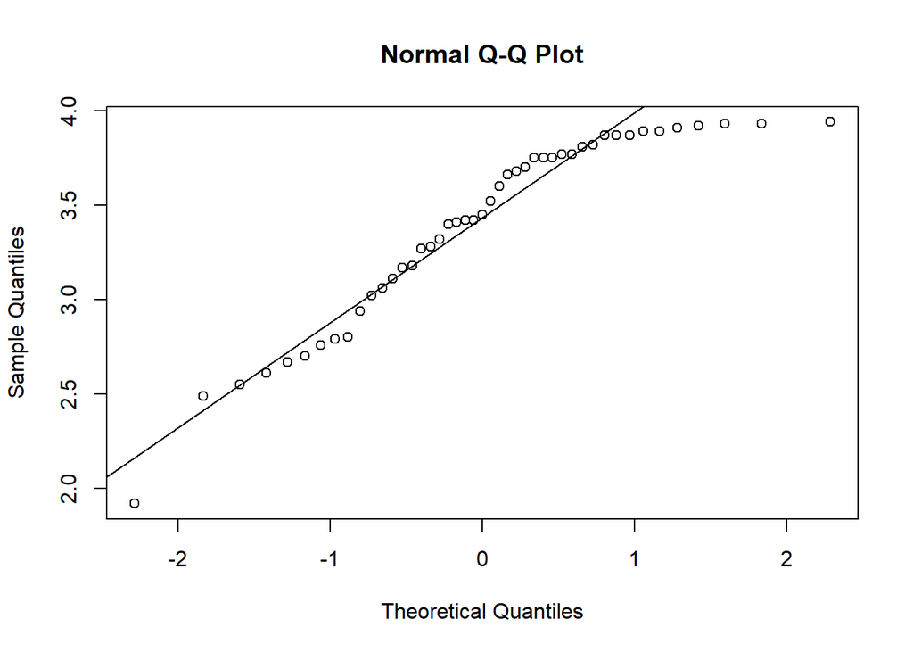

```r
qqnorm(GPA)
qqline(GPA)
```

8. Is there a reason to be concerned for the model in this case?

Yes, given this qq plot we should be concerned that our tests are invalid because the predictor, GPA, is not normally distributed.

9. Produce a density plot of GPA.

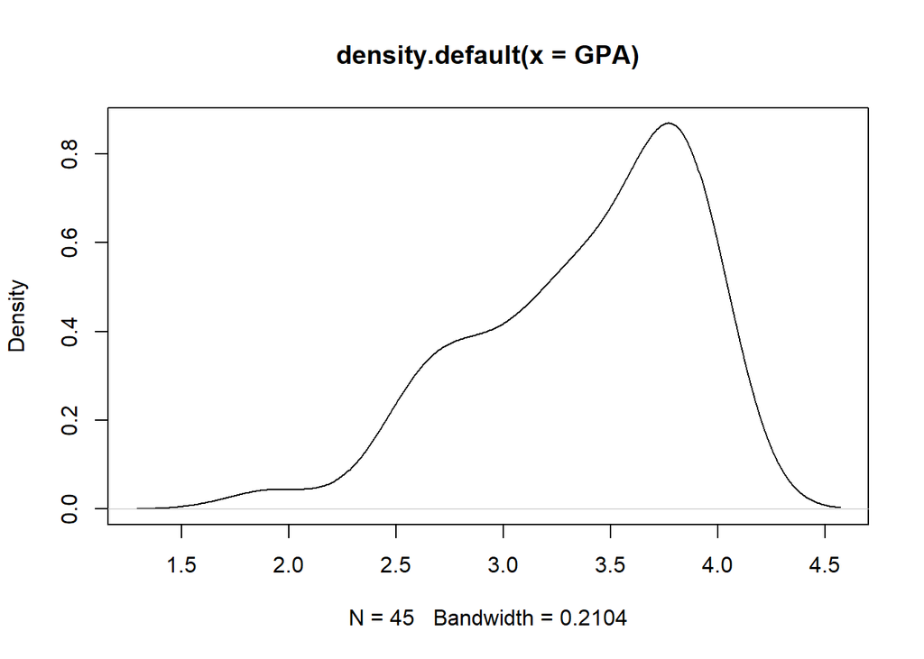

```r
plot(density(GPA))
```

10. What seems to be the issue with the data when you look at the density plot?

From the density plot it is very clear that GPA is non-normally distributed. GPA is significantly left skewed

11. Using the powerTransform function, what transform would you suggest?

```r
powerTransform(GPA)
```

```
## Estimated transformation parameters
##      GPA
## 3.639408
```

12. Try tranforming GPA by raising it to the $4^{th}$ power. Now produce a qq plot.

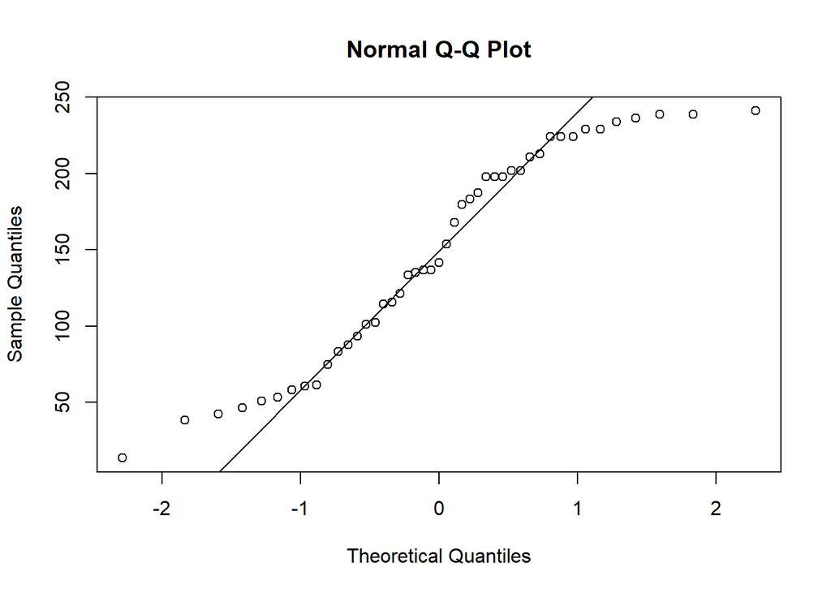

```r
tGPA <- (GPA)^4
qqnorm(tGPA)
qqline(tGPA)
```

13. There still seems to be a problem with normality, but the result is more symmetric and seems to have thin tails, so lets try another fit of the log(odds of passing) as a function of GPA^4. What are the $\hat\beta$’s now?

```r
model2 <- glm(ExamP ~ tGPA, family = 'binomial')
coef(model2)
```

```
## (Intercept)        tGPA
## -3.11205969  0.01303234
```

14. According to the Wald statistic, is the slope of GPA^4 significantly different from 0 at the $\alpha = 0.05$ level? What is the p-value?

```r
summary(model2)
```

```
##
## Call:
## glm(formula = ExamP ~ tGPA, family = "binomial")
##
## Deviance Residuals:
##     Min       1Q   Median       3Q      Max
## -1.1895  -0.8899  -0.4973   1.1788   1.9674
##
## Coefficients:
##              Estimate Std. Error z value Pr(>|z|)
## (Intercept) -3.112060   1.117288  -2.785  0.00535 **
## tGPA         0.013032   0.006061   2.150  0.03155 *
## ---
## Signif. codes:  0 '***' 0.001 '**' 0.01 '*' 0.05 '.' 0.1 ' ' 1
##
## (Dispersion parameter for binomial family taken to be 1)
##
##     Null deviance: 52.192  on 44  degrees of freedom
## Residual deviance: 46.546  on 43  degrees of freedom
## AIC: 50.546
##
## Number of Fisher Scoring iterations: 4
```

The Wald statistic is 2.150 for the slope of tGPA and the p-value is 0.0315 meaning that the slope of GPA^4 is significant;y greater than 0

15. According to the model in 13, what is the point estimate for the log(odds of passing) if the GPA is 3.1?

```r
bhat <- coef(model2)
est <- c(1,(3.1)^4)%*%bhat
est
```

```
##           [,1]
## [1,] -1.908496
```

16. What is the point estimate for the probability of passing with a GPA of 3.1?

```r
exp(est)/(1+exp(est))
```

```
##           [,1]
## [1,] 0.1291499
```

17. Using the model in 13, what does the GPA need to be for the probability of passing to be at least 0.5? (Work to 2 decimal places.)

```r
est1 <- c(1,(3.9311)^4)%*%bhat
exp(est1)/(1+exp(est1))
```

```
##           [,1]
## [1,] 0.5000552
```

So to be totally honest I played around with numbers until I got a GPA that would work. A GPA of 3.9311 will correlate to a .50 passing rate on exam P according to the model from question 13.

18. Produce a plot of the probability of passing as a function of GPA using the model in problem 13.

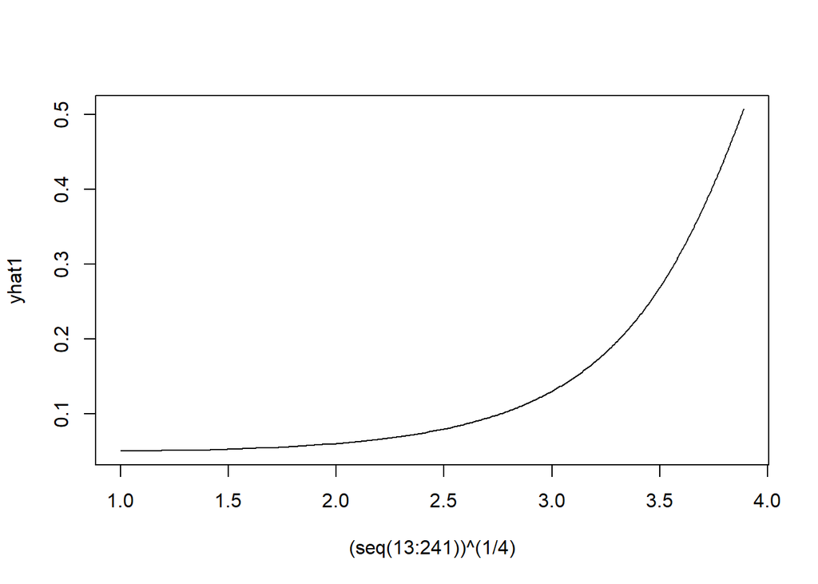

```r
X <- cbind(1,13:241)
yhat1 <- exp(X%*%bhat)/(1+exp(X%*%bhat))
plot((seq(13:241))^(1/4), yhat1, type = 'l')
```

The data in the file called *bird1.dat* have to do with the status of various bird populations. We are going to attempt to build a model to estimate the variable ‘Status’ from the other variables in the data set (excluding ‘Species’). There are 67 observations in the data set. We are going to build a model using 50 of the observations, and test the model on the remaining 17. Use the following code to make a training data set and a test data set.

```r
bird <- read.table('bird1.dat',header=TRUE)
set.seed(23)
aa <- 1:67
train <- sample(aa,50)
trainset <- bird[train,]
testset <- bird[-train,]
```

19. Build a model on the training set using the following variables: Mass, Range, Migr, Insect, Diet, Wood, Water, Indiv. Print a summary of the model. What is the residual deviance of the model?

```r
birdmod <- glm(Status ~ Mass + Range + Migr + Insect + Diet + Wood + Water + Indiv,
               data = trainset, family = 'binomial')
summary(model)
```

```
##
## Call:
## glm(formula = ExamP ~ GPA, family = "binomial")
##
## Deviance Residuals:
##     Min       1Q   Median       3Q      Max
## -1.1626  -0.9273  -0.4783   1.2020   1.9543
##
## Coefficients:
##             Estimate Std. Error z value Pr(>|z|)
## (Intercept)   -8.923      3.835  -2.327   0.0200 *
## GPA            2.256      1.058   2.133   0.0329 *
## ---
## Signif. codes:  0 '***' 0.001 '**' 0.01 '*' 0.05 '.' 0.1 ' ' 1
##
## (Dispersion parameter for binomial family taken to be 1)
##
##     Null deviance: 52.192  on 44  degrees of freedom
## Residual deviance: 45.653  on 43  degrees of freedom
## AIC: 49.653
##
## Number of Fisher Scoring iterations: 5
```

20. Now perform a stepwise procedure on the training set using the model above as the full model and the model with only the intercept as the minimal model. Use AIC as the criterion and step both directions. What terms are in the best model?

```r
birdmin <- glm(Status ~ 1, data = trainset, family = 'binomial')
step(birdmod, scope=list(upper=birdmod,lower=birdmin), direction = 'both', data = trainset)
```

```
## Start:  AIC=33.94
## Status ~ Mass + Range + Migr + Insect + Diet + Wood + Water +
##     Indiv
##
##          Df Deviance    AIC
## - Water   1   15.944 31.944
## - Insect  1   16.038 32.038
## - Range   1   17.075 33.075
## - Migr    1   17.780 33.780
## <none>        15.940 33.940
## - Diet    1   17.987 33.987
## - Wood    1   18.772 34.772
## - Mass    1   30.768 46.768
## - Indiv   1   51.931 67.931
##
## Step:  AIC=31.94
## Status ~ Mass + Range + Migr + Insect + Diet + Wood + Indiv
##
##          Df Deviance    AIC
## - Insect  1   16.038 30.038
## - Range   1   17.091 31.091
## <none>        15.944 31.944
## - Diet    1   17.987 31.987
## - Migr    1   18.351 32.351
## - Wood    1   18.882 32.882
## + Water   1   15.940 33.940
## - Mass    1   34.312 48.312
## - Indiv   1   52.927 66.927
##
## Step:  AIC=30.04
## Status ~ Mass + Range + Migr + Diet + Wood + Indiv
##
##          Df Deviance    AIC
## - Range   1   17.141 29.141
## <none>        16.038 30.038
## - Migr    1   18.361 30.361
## + Insect  1   15.944 31.944
## + Water   1   16.038 32.038
## - Wood    1   20.374 32.374
## - Diet    1   24.047 36.047
```

[output cut: 15 more lines]

```
## - Indiv   1   56.291 66.291
##
## Step:  AIC=28.43
## Status ~ Mass + Diet + Wood + Indiv
##
##          Df Deviance    AIC
## <none>        18.428 28.428
## + Migr    1   17.141 29.141
## + Water   1   18.024 30.024
## + Range   1   18.361 30.361
## + Insect  1   18.416 30.416
## - Wood    1   24.356 32.356
## - Diet    1   25.752 33.752
## - Mass    1   36.080 44.080
## - Indiv   1   59.693 67.693
```

```
##
## Call:  glm(formula = Status ~ Mass + Diet + Wood + Indiv, family = "binomial",
##     data = trainset)
##
## Coefficients:
## (Intercept)         Mass         Diet         Wood        Indiv
##  -14.788889     0.003429     3.495078     3.732210     0.015910
##
## Degrees of Freedom: 49 Total (i.e. Null);  45 Residual
## Null Deviance:       64.1
## Residual Deviance: 18.43     AIC: 28.43
```

The terms of the best model from this process are Mass, Diet, Wood, and Indiv.

21. Print a summary of the best model. What is the residual deviance of this model?

```r
birdm1 <- glm(Status ~ Mass + Diet + Wood + Indiv, family = "binomial", data = trainset)
summary(birdm1)
```

```
##
## Call:
## glm(formula = Status ~ Mass + Diet + Wood + Indiv, family = "binomial",
##     data = trainset)
##
## Deviance Residuals:
##      Min        1Q    Median        3Q       Max
## -1.52370  -0.20221  -0.03340   0.04938   2.77060
##
## Coefficients:
##               Estimate Std. Error z value Pr(>|z|)
## (Intercept) -14.788889   5.538681  -2.670  0.00758 **
## Mass          0.003429   0.001315   2.608  0.00910 **
## Diet          3.495078   1.657419   2.109  0.03497 *
## Wood          3.732210   1.875649   1.990  0.04661 *
## Indiv         0.015910   0.005413   2.939  0.00329 **
## ---
## Signif. codes:  0 '***' 0.001 '**' 0.01 '*' 0.05 '.' 0.1 ' ' 1
##
## (Dispersion parameter for binomial family taken to be 1)
##
##     Null deviance: 64.104  on 49  degrees of freedom
## Residual deviance: 18.428  on 45  degrees of freedom
## AIC: 28.428
##
## Number of Fisher Scoring iterations: 8
```

The residual deviance of this model is 18.428.

22. Now do the same stepwise procedure on the training set using a larger penalty. Use k=7 in this run. Now what terms are in the best model?

```r
step(birdmod, scope=list(upper=birdmod,lower=birdmin), direction = 'both', data = trainset, k=7)
```

```
## Start:  AIC=78.94
## Status ~ Mass + Range + Migr + Insect + Diet + Wood + Water +
##     Indiv
##
##          Df Deviance     AIC
## - Water   1   15.944  71.944
## - Insect  1   16.038  72.038
## - Range   1   17.075  73.075
## - Migr    1   17.780  73.780
## - Diet    1   17.987  73.987
## - Wood    1   18.772  74.772
## <none>        15.940  78.940
## - Mass    1   30.768  86.768
## - Indiv   1   51.931 107.931
##
## Step:  AIC=71.94
## Status ~ Mass + Range + Migr + Insect + Diet + Wood + Indiv
##
##          Df Deviance     AIC
## - Insect  1   16.038  65.038
## - Range   1   17.091  66.091
## - Diet    1   17.987  66.987
## - Migr    1   18.351  67.351
## - Wood    1   18.882  67.882
## <none>        15.944  71.944
## + Water   1   15.940  78.940
## - Mass    1   34.312  83.312
## - Indiv   1   52.927 101.927
##
## Step:  AIC=65.04
## Status ~ Mass + Range + Migr + Diet + Wood + Indiv
##
##          Df Deviance    AIC
## - Range   1   17.141 59.141
## - Migr    1   18.361 60.361
## - Wood    1   20.374 62.374
## <none>        16.038 65.038
## - Diet    1   24.047 66.047
## + Insect  1   15.944 71.944
## + Water   1   16.038 72.038
```

[output cut: 29 more lines]

```
## - Indiv   1   59.693 87.693
##
## Step:  AIC=52.36
## Status ~ Mass + Diet + Indiv
##
##          Df Deviance    AIC
## <none>        24.356 52.356
## - Diet    1   31.908 52.908
## + Wood    1   18.428 53.428
## + Migr    1   21.016 56.016
## + Water   1   22.408 57.408
## - Mass    1   36.571 57.571
## + Insect  1   23.014 58.014
## + Range   1   24.219 59.219
## - Indiv   1   62.574 83.574
```

```
##
## Call:  glm(formula = Status ~ Mass + Diet + Indiv, family = "binomial",
##     data = trainset)
##
## Coefficients:
## (Intercept)         Mass         Diet        Indiv
##   -9.541553     0.002081     2.664286     0.013866
##
## Degrees of Freedom: 49 Total (i.e. Null);  46 Residual
## Null Deviance:       64.1
## Residual Deviance: 24.36     AIC: 32.36
```

This method produces a model including Mass, Diet, and Indiv.

23. Print a summary of the best model using k=7. What is the residual deviance of this model?

```r
birdm2 <- glm(Status ~ Mass + Diet + Indiv, family = "binomial", data = trainset)
summary(birdm2)
```

```
##
## Call:
## glm(formula = Status ~ Mass + Diet + Indiv, family = "binomial",
##     data = trainset)
##
## Deviance Residuals:
##     Min       1Q   Median       3Q      Max
## -2.5829  -0.3164  -0.1139   0.1126   1.5372
##
## Coefficients:
##               Estimate Std. Error z value Pr(>|z|)
## (Intercept) -9.5415530  3.3594827  -2.840  0.00451 **
## Mass         0.0020810  0.0008101   2.569  0.01020 *
## Diet         2.6642858  1.1709336   2.275  0.02288 *
## Indiv        0.0138662  0.0042685   3.248  0.00116 **
## ---
## Signif. codes:  0 '***' 0.001 '**' 0.01 '*' 0.05 '.' 0.1 ' ' 1
##
## (Dispersion parameter for binomial family taken to be 1)
##
##     Null deviance: 64.104  on 49  degrees of freedom
## Residual deviance: 24.356  on 46  degrees of freedom
## AIC: 32.356
##
## Number of Fisher Scoring iterations: 7
```

The residual deviance is 24.356

24. What is the p-value for the coefficient of Wood in the AIC model?

The p-value for Wood in the AIC model is 0.04661

25. What is the p-value for the likelihood ratio test comparing the model using AIC with the model using k=7?

```r
anova(birdm2, birdm1)
```

```
## Analysis of Deviance Table
##
## Model 1: Status ~ Mass + Diet + Indiv
## Model 2: Status ~ Mass + Diet + Wood + Indiv
##   Resid. Df Resid. Dev Df Deviance
## 1        46     24.356
## 2        45     18.428  1   5.9279
```

```r
1 - pchisq(birdm2$deviance - birdm1$deviance, 1)
```

```
## [1] 0.01490259
```

26. We will call the model using AIC the AIC model and the model using k=7 the k7 model. Now predict the 17 observations in the test set using the AIC model. What is the error sum of squares for the predicted values?

```r
birdt1 <- glm(Status ~ Mass + Diet + Wood + Indiv, family = "binomial", data = testset)
X1test <- model.matrix(birdt1)
beta1 <- coef(birdt1)
p1 <- exp(X1test%*%beta1) / (1+exp(X1test%*%beta1))
m1SSE <- sum((testset$Status - p1)^2, na.rm = TRUE)
m1SSE
```

```
## [1] 1.012178e-17
```

27. What is the median absolute deviation for the AIC model?

```r
m1MAD <- median(abs(testset$Status - p1), na.rm = TRUE)
m1MAD
```

```
## [1] 1.938266e-13
```

28. Now predict the 17 observations in the test set using the k7 model. What is the error sum of squares for the predicted values?

```r
birdt2 <- glm(Status ~ Mass + Diet + Indiv, family = "binomial", data = testset)
X2test <- model.matrix(birdt2)
beta2 <- coef(birdt2)
p2 <- exp(X2test%*%beta2) / (1+exp(X2test%*%beta2))
m2SSE <- sum((testset$Status - p2)^2, na.rm = TRUE)
m2SSE
```

```
## [1] 6.536504e-18
```

29. What is the median absolute deviation for the k7 model?

```r
m2MAD <- median(abs(testset$Status - p2), na.rm = TRUE)
m2MAD
```

```
## [1] 7.437655e-14
```

30. Based on all the output we have looked at, which model would you use to predict Status in the future?

I would rely more on the model produced with k = 7 because both its SSE and MAD are lower than the AIC model and is more parsimonious as well.